# **Predicting MOE of Wood Samples using Near-Infrared Spectroscopy**

## Project Description

This project aims to build regression models to predict the Modulus of Elasticity (MOE) of new wood samples using Near-Infrared (NIR) spectroscopy data. The goal is to find a way to predict the MOE of a new sample without conducting the expensive and time-consuming bending test, which is typically used to measure MOE.

The dataset for this project was obtained from an experimental test on lots of wood samples. The NIR sensor was used to measure the signals at 692 different wavelengths for 2018 wood samples. The last column of the dataset, titled "Modulus of Elasticity (MOE)", contains the MOE values obtained through a bending test for each sample.

The project will follow the steps outlined in the problem statement:

1. Data Preparation: The provided CSV file contains the NIR measurements and the MOE values (output) for 2018 wood samples. The data will be split into 80/20 Train/Test sets.
2. Feature Scaling: The data will be examined for the need of dimensionality reduction. If required, Principal Component Analysis (PCA) will be performed on the data and the results will be compared. Regression Modeling: Several regression methods will be explored, including:
   1. Regular ML Methods without PCA - Linear Regression, Polynomial Regression and Support Vector Regression
   2. ANN without PCA
   3. Regular ML Methods with PCA
   4. ANN with PCA The performance of these models will be evaluated and compared using appropriate metrics, such as R-squared.
3. Model Selection: The best-performing regression model will be selected to predict the MOE of new wood samples based on their NIR measurements

The project will follow the steps outlined in the problem statement to explore various regression techniques, assess the need for dimensionality reduction, and ultimately select the best-performing model to predict the MOE of new wood samples based on their NIR measurements.

The outcome of this project will be a robust regression model that can accurately predict the MOE of new wood samples using their NIR spectroscopy data, without the need for the expensive bending test.

# 1. Imports and Dependencies

```python
import numpy as np
import pandas as pd
import matplotlib.pyplot as plt
import seaborn as sns
from sklearn.metrics import r2_score, confusion_matrix, accuracy_score  # For model evaluation metrics
```

# 2. Data Loading and Preprocessing

## 2.1 Data Loading

```python
df = pd.read_csv('Dataset.csv')
df.head()
```

|  | X1 | X2 | X3 | X4 | X5 | X6 | X7 | X8 | X9 | X10 | ... | X684 | X685 | X686 | X687 | X688 | X689 | X690 | X691 | X692 | MOE |
| --- | --- | --- | --- | --- | --- | --- | --- | --- | --- | --- | --- | --- | --- | --- | --- | --- | --- | --- | --- | --- | --- |
| 0 | 0.000068 | 0.000074 | 0.000085 | 0.000094 | 0.000099 | 0.000102 | 0.000098 | 0.000092 | 0.000079 | 0.000057 | ... | -0.000081 | -0.000089 | -0.000104 | -0.000115 | -0.000114 | -0.000110 | -0.000108 | -0.000106 | -0.000116 | 36.300956 |
| 1 | 0.000065 | 0.000071 | 0.000082 | 0.000091 | 0.000094 | 0.000094 | 0.000086 | 0.000074 | 0.000056 | 0.000033 | ... | -0.000117 | -0.000120 | -0.000117 | -0.000117 | -0.000123 | -0.000128 | -0.000136 | -0.000138 | -0.000141 | 36.315318 |
| 2 | 0.000077 | 0.000083 | 0.000093 | 0.000100 | 0.000101 | 0.000102 | 0.000096 | 0.000085 | 0.000068 | 0.000044 | ... | -0.000142 | -0.000151 | -0.000172 | -0.000185 | -0.000200 | -0.000205 | -0.000204 | -0.000210 | -0.000213 | 40.512312 |
| 3 | 0.000074 | 0.000079 | 0.000089 | 0.000097 | 0.000101 | 0.000102 | 0.000097 | 0.000087 | 0.000071 | 0.000049 | ... | -0.000162 | -0.000178 | -0.000194 | -0.000200 | -0.000215 | -0.000223 | -0.000224 | -0.000227 | -0.000231 | 39.837054 |
| 4 | 0.000078 | 0.000084 | 0.000093 | 0.000102 | 0.000106 | 0.000108 | 0.000102 | 0.000093 | 0.000077 | 0.000054 | ... | -0.000165 | -0.000198 | -0.000215 | -0.000215 | -0.000227 | -0.000220 | -0.000215 | -0.000203 | -0.000201 | 42.003827 |

5 rows × 693 columns

## 2.2 Exploratory Data Analysis

### 2.2.1 Check for missing values

```python
# Dictionary to store the result
missing_data_info = {}

# Iterate over each column to check for missing values
for column in df.columns:
    has_missing_data = df[column].isnull().any()
    missing_count = df[column].isnull().sum()
    missing_data_info[column] = {"has_missing": has_missing_data, "missing_count": missing_count}

# Convert the results to a DataFrame for a clean summary
missing_summary = pd.DataFrame(missing_data_info).T
missing_summary.index.name = 'Column'
print(missing_summary)
```

```
       has_missing missing_count
Column
X1           False             0
X2           False             0
X3           False             0
X4           False             0
X5           False             0
...            ...           ...
X689         False             0
X690         False             0
X691         False             0
X692         False             0
MOE          False             0

[693 rows x 2 columns]
```

No missing Data is present.

### 2.2.2 Check overall data information

```python
df.describe()
```

|  | X1 | X2 | X3 | X4 | X5 | X6 | X7 | X8 | X9 | X10 | ... | X684 | X685 | X686 | X687 | X688 | X689 | X690 | X691 | X692 | MOE |
| --- | --- | --- | --- | --- | --- | --- | --- | --- | --- | --- | --- | --- | --- | --- | --- | --- | --- | --- | --- | --- | --- |
| count | 2018.000000 | 2018.000000 | 2018.000000 | 2018.000000 | 2018.000000 | 2018.000000 | 2018.000000 | 2018.000000 | 2018.000000 | 2018.000000 | ... | 2018.000000 | 2018.000000 | 2018.000000 | 2018.000000 | 2018.000000 | 2018.000000 | 2018.000000 | 2018.000000 | 2018.000000 | 2018.000000 |
| mean | 0.000074 | 0.000080 | 0.000090 | 0.000097 | 0.000101 | 0.000102 | 0.000097 | 0.000088 | 0.000072 | 0.000049 | ... | -0.000152 | -0.000167 | -0.000181 | -0.000190 | -0.000199 | -0.000203 | -0.000208 | -0.000207 | -0.000207 | 40.667764 |
| std | 0.000015 | 0.000015 | 0.000016 | 0.000017 | 0.000017 | 0.000017 | 0.000017 | 0.000017 | 0.000017 | 0.000015 | ... | 0.000022 | 0.000024 | 0.000027 | 0.000029 | 0.000031 | 0.000033 | 0.000034 | 0.000033 | 0.000033 | 2.758824 |
| min | 0.000018 | 0.000030 | 0.000040 | 0.000046 | 0.000047 | 0.000046 | 0.000041 | 0.000038 | 0.000032 | 0.000021 | ... | -0.000209 | -0.000221 | -0.000239 | -0.000247 | -0.000261 | -0.000264 | -0.000289 | -0.000269 | -0.000270 | 31.860027 |
| 25% | 0.000066 | 0.000071 | 0.000079 | 0.000086 | 0.000090 | 0.000091 | 0.000086 | 0.000077 | 0.000063 | 0.000042 | ... | -0.000166 | -0.000183 | -0.000198 | -0.000210 | -0.000220 | -0.000225 | -0.000230 | -0.000229 | -0.000229 | 38.836328 |
| 50% | 0.000074 | 0.000080 | 0.000089 | 0.000097 | 0.000100 | 0.000102 | 0.000096 | 0.000087 | 0.000071 | 0.000048 | ... | -0.000156 | -0.000171 | -0.000186 | -0.000196 | -0.000207 | -0.000211 | -0.000217 | -0.000217 | -0.000217 | 40.806908 |
| 75% | 0.000082 | 0.000088 | 0.000099 | 0.000107 | 0.000111 | 0.000112 | 0.000107 | 0.000097 | 0.000080 | 0.000055 | ... | -0.000142 | -0.000156 | -0.000169 | -0.000179 | -0.000189 | -0.000193 | -0.000197 | -0.000194 | -0.000193 | 42.674695 |
| max | 0.000216 | 0.000217 | 0.000235 | 0.000244 | 0.000243 | 0.000242 | 0.000233 | 0.000249 | 0.000258 | 0.000244 | ... | -0.000051 | -0.000062 | -0.000071 | -0.000069 | -0.000063 | -0.000047 | -0.000045 | -0.000046 | -0.000048 | 48.919894 |

8 rows × 693 columns

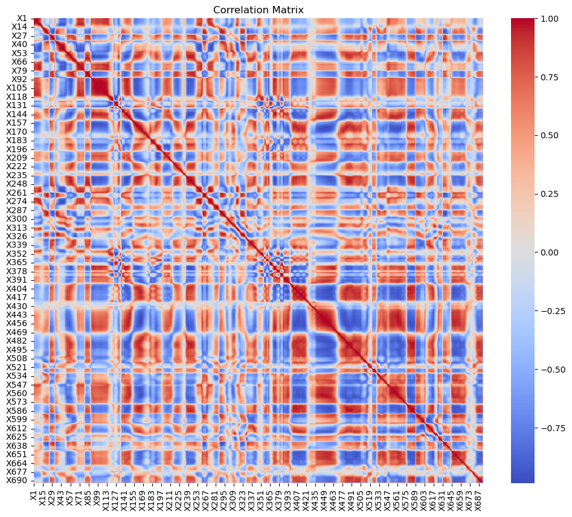

```python
# Calculate the correlation matrix
corr_matrix = df.corr()

# Plot the correlation matrix
plt.figure(figsize=(12, 10))  # Adjust the size for better visibility
sns.heatmap(corr_matrix, cmap='coolwarm', annot=False, fmt='.2f')
plt.title('Correlation Matrix')
plt.show()
```

The matrix shows a mix of positive (red) and negative (blue) correlations between the features, indicating both positive and negative linear relationships.

## 2.3 Separate input and output and split dataset

```python
#Split data into feature and target
X = df.iloc[:, :692] # sets first 692 columns as input
y = df.iloc[:, 692] # sets last column as output

X.describe()
```

|  | X1 | X2 | X3 | X4 | X5 | X6 | X7 | X8 | X9 | X10 | ... | X683 | X684 | X685 | X686 | X687 | X688 | X689 | X690 | X691 | X692 |
| --- | --- | --- | --- | --- | --- | --- | --- | --- | --- | --- | --- | --- | --- | --- | --- | --- | --- | --- | --- | --- | --- |
| count | 2018.000000 | 2018.000000 | 2018.000000 | 2018.000000 | 2018.000000 | 2018.000000 | 2018.000000 | 2018.000000 | 2018.000000 | 2018.000000 | ... | 2018.000000 | 2018.000000 | 2018.000000 | 2018.000000 | 2018.000000 | 2018.000000 | 2018.000000 | 2018.000000 | 2018.000000 | 2018.000000 |
| mean | 0.000074 | 0.000080 | 0.000090 | 0.000097 | 0.000101 | 0.000102 | 0.000097 | 0.000088 | 0.000072 | 0.000049 | ... | -0.000134 | -0.000152 | -0.000167 | -0.000181 | -0.000190 | -0.000199 | -0.000203 | -0.000208 | -0.000207 | -0.000207 |
| std | 0.000015 | 0.000015 | 0.000016 | 0.000017 | 0.000017 | 0.000017 | 0.000017 | 0.000017 | 0.000017 | 0.000015 | ... | 0.000021 | 0.000022 | 0.000024 | 0.000027 | 0.000029 | 0.000031 | 0.000033 | 0.000034 | 0.000033 | 0.000033 |
| min | 0.000018 | 0.000030 | 0.000040 | 0.000046 | 0.000047 | 0.000046 | 0.000041 | 0.000038 | 0.000032 | 0.000021 | ... | -0.000230 | -0.000209 | -0.000221 | -0.000239 | -0.000247 | -0.000261 | -0.000264 | -0.000289 | -0.000269 | -0.000270 |
| 25% | 0.000066 | 0.000071 | 0.000079 | 0.000086 | 0.000090 | 0.000091 | 0.000086 | 0.000077 | 0.000063 | 0.000042 | ... | -0.000147 | -0.000166 | -0.000183 | -0.000198 | -0.000210 | -0.000220 | -0.000225 | -0.000230 | -0.000229 | -0.000229 |
| 50% | 0.000074 | 0.000080 | 0.000089 | 0.000097 | 0.000100 | 0.000102 | 0.000096 | 0.000087 | 0.000071 | 0.000048 | ... | -0.000136 | -0.000156 | -0.000171 | -0.000186 | -0.000196 | -0.000207 | -0.000211 | -0.000217 | -0.000217 | -0.000217 |
| 75% | 0.000082 | 0.000088 | 0.000099 | 0.000107 | 0.000111 | 0.000112 | 0.000107 | 0.000097 | 0.000080 | 0.000055 | ... | -0.000123 | -0.000142 | -0.000156 | -0.000169 | -0.000179 | -0.000189 | -0.000193 | -0.000197 | -0.000194 | -0.000193 |
| max | 0.000216 | 0.000217 | 0.000235 | 0.000244 | 0.000243 | 0.000242 | 0.000233 | 0.000249 | 0.000258 | 0.000244 | ... | -0.000041 | -0.000051 | -0.000062 | -0.000071 | -0.000069 | -0.000063 | -0.000047 | -0.000045 | -0.000046 | -0.000048 |

8 rows × 692 columns

```python
from sklearn.model_selection import train_test_split

# Split the dataset into 80/20
X_train, X_test, y_train, y_test = train_test_split(X, y, test_size = 0.2,random_state = 42)

#Visualize the training input data
print(X_train.info())
print(y_train.info())

y_train.shape
```

```
<class 'pandas.core.frame.DataFrame'>
Int64Index: 1614 entries, 746 to 1126
Columns: 692 entries, X1 to X692
dtypes: float64(692)
memory usage: 8.5 MB
None
<class 'pandas.core.series.Series'>
Int64Index: 1614 entries, 746 to 1126
Series name: MOE
Non-Null Count  Dtype
--------------  -----
1614 non-null   float64
dtypes: float64(1)
memory usage: 25.2 KB
None
```

```
(1614,)
```

## 2.4 Scaling

```python
from sklearn.preprocessing import StandardScaler

scaler_x = StandardScaler()
scaler_y = StandardScaler()

# Fit the scaler on the training data and transform both train and test data
X_train_scaled = scaler_x.fit_transform(X_train)
X_test_scaled = scaler_x.transform(X_test)

# # Convert y_train and y_test to numpy arrays, then reshape to 2D
# y_train_scaled = scaler_y.fit_transform(y_train.to_numpy().reshape(-1, 1))  # Ensure y_train is reshaped to 2D
# y_test_scaled = scaler_y.transform(y_test.to_numpy().reshape(-1, 1))  # Ensure y_test is reshaped to 2D

print("X_train_scaled shape:", X_train_scaled.shape)
print("y_train_scaled shape:", y_train.to_numpy().reshape(-1, 1).shape)
```

```
X_train_scaled shape: (1614, 692)
y_train_scaled shape: (1614, 1)
```

# 3. Model Development

## 3.1 Linear Regression without PCA

```python
from sklearn.linear_model import LinearRegression
# Apply linear regression
LinearRegModel = LinearRegression()
LinearRegModel.fit(X_train_scaled, y_train)

# Predict on test data
y_simple_pred_train = LinearRegModel.predict(X_train_scaled)
y_simple_pred_test = LinearRegModel.predict(X_test_scaled)

#Assess the accuracy of the model
# Calculate metrics (r2_score)
r2_train = r2_score(y_train, y_simple_pred_train)
r2_test = r2_score(y_test, y_simple_pred_test)

print(f"Training R² score: {r2_train:.4f}")
print(f"Test R² score: {r2_test:.4f}")
```

```
Training R² score: 0.8319
Test R² score: 0.3601
```

## 3.2 Polynomial Regression without PCA

```python
from sklearn.preprocessing import PolynomialFeatures # For feature scaling & polynomial regression

# Apply polynomial Regression

results = []

poly_reg = PolynomialFeatures(degree = 2)
X_poly = poly_reg.fit_transform(X_train_scaled)
Model2= LinearRegression()

X_poly.shape

# Model2.fit(X_poly, y_train)
```

```
(1614, 240471)
```

It seems like my computer blows up when I try any Polynomial regression above degree with 692 features

## 3.3 Support Vector Regression

```python
from sklearn.svm import SVR  # For Support Vector Regression

SVMModel = SVR(kernel = 'rbf')
SVMModel.fit(X_train_scaled, y_train)

# test model
y_pred = SVMModel.predict(X_test_scaled)
y_train_SVM = SVMModel.predict(X_train_scaled)

# Calculate metrics (r2_score)
r2_train = r2_score(y_train, y_train_SVM)
r2_test = r2_score(y_test,y_pred)

print(f"Training R² score: {r2_train:.4f}")
print(f"Test R² score: {r2_test:.4f}")
```

```
Training R² score: 0.7091
Test R² score: 0.5823
```

## 3.4 ANN without PCA

```python
import tensorflow as tf
from tensorflow import keras
from keras import callbacks
```

```
51/51 ━━━━━━━━━━━━━━━━━━━━ 2s 14ms/step - loss: 533.9049 - mae: 18.0762 - val_loss: 87.4591 - val_mae: 6.6831
51/51 ━━━━━━━━━━━━━━━━━━━━ 1s 11ms/step - loss: 74.0102 - mae: 5.9264 - val_loss: 60.6852 - val_mae: 5.0514
51/51 ━━━━━━━━━━━━━━━━━━━━ 1s 13ms/step - loss: 57.4420 - mae: 4.8400 - val_loss: 50.1139 - val_mae: 4.5858
51/51 ━━━━━━━━━━━━━━━━━━━━ 1s 11ms/step - loss: 46.5747 - mae: 4.2938 - val_loss: 40.5694 - val_mae: 3.9309
51/51 ━━━━━━━━━━━━━━━━━━━━ 1s 11ms/step - loss: 38.0636 - mae: 3.7420 - val_loss: 45.5254 - val_mae: 4.2865
51/51 ━━━━━━━━━━━━━━━━━━━━ 1s 12ms/step - loss: 34.3681 - mae: 3.4867 - val_loss: 39.6065 - val_mae: 3.9508
51/51 ━━━━━━━━━━━━━━━━━━━━ 1s 10ms/step - loss: 31.9718 - mae: 3.2878 - val_loss: 34.9814 - val_mae: 3.6728
51/51 ━━━━━━━━━━━━━━━━━━━━ 1s 12ms/step - loss: 31.7398 - mae: 3.3105 - val_loss: 35.6959 - val_mae: 3.7643
51/51 ━━━━━━━━━━━━━━━━━━━━ 1s 11ms/step - loss: 27.2293 - mae: 2.9192 - val_loss: 37.9344 - val_mae: 3.8536
51/51 ━━━━━━━━━━━━━━━━━━━━ 1s 13ms/step - loss: 31.1356 - mae: 3.1632 - val_loss: 32.4355 - val_mae: 3.5285
51/51 ━━━━━━━━━━━━━━━━━━━━ 1s 11ms/step - loss: 25.9056 - mae: 2.9339 - val_loss: 31.8972 - val_mae: 3.5134
51/51 ━━━━━━━━━━━━━━━━━━━━ 1s 12ms/step - loss: 27.0891 - mae: 3.1693 - val_loss: 27.7736 - val_mae: 3.1565
51/51 ━━━━━━━━━━━━━━━━━━━━ 1s 11ms/step - loss: 21.0553 - mae: 2.4243 - val_loss: 31.8573 - val_mae: 3.5160
51/51 ━━━━━━━━━━━━━━━━━━━━ 1s 12ms/step - loss: 18.9684 - mae: 2.2805 - val_loss: 27.0123 - val_mae: 3.2102
51/51 ━━━━━━━━━━━━━━━━━━━━ 1s 11ms/step - loss: 20.1951 - mae: 2.5121 - val_loss: 26.4964 - val_mae: 3.1805
51/51 ━━━━━━━━━━━━━━━━━━━━ 1s 13ms/step - loss: 23.7245 - mae: 2.7303 - val_loss: 26.5933 - val_mae: 3.2420
51/51 ━━━━━━━━━━━━━━━━━━━━ 1s 11ms/step - loss: 18.7185 - mae: 2.3210 - val_loss: 31.3703 - val_mae: 3.7708
51/51 ━━━━━━━━━━━━━━━━━━━━ 1s 12ms/step - loss: 22.0552 - mae: 2.7770 - val_loss: 32.4701 - val_mae: 3.9492
51/51 ━━━━━━━━━━━━━━━━━━━━ 1s 11ms/step - loss: 20.4940 - mae: 2.6203 - val_loss: 22.9900 - val_mae: 2.8458
51/51 ━━━━━━━━━━━━━━━━━━━━ 1s 11ms/step - loss: 15.4660 - mae: 1.9605 - val_loss: 26.7396 - val_mae: 3.2784
51/51 ━━━━━━━━━━━━━━━━━━━━ 1s 11ms/step - loss: 21.3329 - mae: 2.7049 - val_loss: 22.3747 - val_mae: 2.8773
51/51 ━━━━━━━━━━━━━━━━━━━━ 1s 11ms/step - loss: 15.0761 - mae: 2.0601 - val_loss: 24.3969 - val_mae: 3.1521
51/51 ━━━━━━━━━━━━━━━━━━━━ 1s 12ms/step - loss: 14.5677 - mae: 1.9714 - val_loss: 24.4684 - val_mae: 3.2164
51/51 ━━━━━━━━━━━━━━━━━━━━ 1s 12ms/step - loss: 16.2646 - mae: 2.2633 - val_loss: 21.3062 - val_mae: 2.8916
51/51 ━━━━━━━━━━━━━━━━━━━━ 1s 11ms/step - loss: 14.6024 - mae: 2.0375 - val_loss: 22.8543 - val_mae: 3.0405
51/51 ━━━━━━━━━━━━━━━━━━━━ 1s 11ms/step - loss: 13.2306 - mae: 1.8648 - val_loss: 24.9765 - val_mae: 3.2205
51/51 ━━━━━━━━━━━━━━━━━━━━ 1s 12ms/step - loss: 14.0107 - mae: 2.0194 - val_loss: 20.3589 - val_mae: 2.8426
51/51 ━━━━━━━━━━━━━━━━━━━━ 1s 11ms/step - loss: 12.8040 - mae: 1.8233 - val_loss: 27.9478 - val_mae: 3.5505
51/51 ━━━━━━━━━━━━━━━━━━━━ 1s 12ms/step - loss: 14.8857 - mae: 2.2204 - val_loss: 21.3815 - val_mae: 2.9970
51/51 ━━━━━━━━━━━━━━━━━━━━ 1s 11ms/step - loss: 13.7593 - mae: 2.0150 - val_loss: 21.1826 - val_mae: 3.0998
51/51 ━━━━━━━━━━━━━━━━━━━━ 1s 13ms/step - loss: 15.9837 - mae: 2.3850 - val_loss: 19.8311 - val_mae: 2.7819
51/51 ━━━━━━━━━━━━━━━━━━━━ 1s 11ms/step - loss: 10.8153 - mae: 1.6262 - val_loss: 18.8070 - val_mae: 2.7933
51/51 ━━━━━━━━━━━━━━━━━━━━ 1s 12ms/step - loss: 10.5771 - mae: 1.6068 - val_loss: 18.7894 - val_mae: 2.7718
51/51 ━━━━━━━━━━━━━━━━━━━━ 1s 12ms/step - loss: 10.7312 - mae: 1.7184 - val_loss: 18.6074 - val_mae: 2.7703
51/51 ━━━━━━━━━━━━━━━━━━━━ 1s 13ms/step - loss: 10.4619 - mae: 1.7048 - val_loss: 19.5448 - val_mae: 2.8783
51/51 ━━━━━━━━━━━━━━━━━━━━ 1s 12ms/step - loss: 9.2550 - mae: 1.5107 - val_loss: 17.9257 - val_mae: 2.6803
51/51 ━━━━━━━━━━━━━━━━━━━━ 1s 14ms/step - loss: 8.3781 - mae: 1.3086 - val_loss: 19.6450 - val_mae: 2.9601
51/51 ━━━━━━━━━━━━━━━━━━━━ 1s 12ms/step - loss: 8.2812 - mae: 1.3555 - val_loss: 20.0175 - val_mae: 3.1674
51/51 ━━━━━━━━━━━━━━━━━━━━ 1s 12ms/step - loss: 11.6378 - mae: 2.0665 - val_loss: 16.6494 - val_mae: 2.6179
51/51 ━━━━━━━━━━━━━━━━━━━━ 1s 11ms/step - loss: 8.6600 - mae: 1.4550 - val_loss: 19.0023 - val_mae: 2.9216
51/51 ━━━━━━━━━━━━━━━━━━━━ 1s 12ms/step - loss: 8.9099 - mae: 1.5597 - val_loss: 17.2199 - val_mae: 2.7574
51/51 ━━━━━━━━━━━━━━━━━━━━ 1s 12ms/step - loss: 7.6714 - mae: 1.3559 - val_loss: 17.2397 - val_mae: 2.7923
51/51 ━━━━━━━━━━━━━━━━━━━━ 1s 12ms/step - loss: 8.3752 - mae: 1.4914 - val_loss: 17.5084 - val_mae: 2.7676
51/51 ━━━━━━━━━━━━━━━━━━━━ 1s 12ms/step - loss: 9.1320 - mae: 1.6224 - val_loss: 16.5773 - val_mae: 2.6730
51/51 ━━━━━━━━━━━━━━━━━━━━ 1s 14ms/step - loss: 8.0044 - mae: 1.3995 - val_loss: 17.3841 - val_mae: 2.8065
51/51 ━━━━━━━━━━━━━━━━━━━━ 1s 13ms/step - loss: 15.7983 - mae: 2.6251 - val_loss: 37.1893 - val_mae: 4.2957
51/51 ━━━━━━━━━━━━━━━━━━━━ 1s 12ms/step - loss: 22.9790 - mae: 3.2483 - val_loss: 22.4851 - val_mae: 3.4301
51/51 ━━━━━━━━━━━━━━━━━━━━ 1s 14ms/step - loss: 14.2805 - mae: 2.5245 - val_loss: 30.1707 - val_mae: 3.9796
51/51 ━━━━━━━━━━━━━━━━━━━━ 1s 12ms/step - loss: 13.8124 - mae: 2.1763 - val_loss: 26.7092 - val_mae: 3.5656
51/51 ━━━━━━━━━━━━━━━━━━━━ 1s 12ms/step - loss: 14.4906 - mae: 2.4398 - val_loss: 20.4885 - val_mae: 3.2780
51/51 ━━━━━━━━━━━━━━━━━━━━ 0s 3ms/step
13/13 ━━━━━━━━━━━━━━━━━━━━ 0s 8ms/step
ANN Training R² score: -0.3522
ANN Test R² score: -1.5806
```

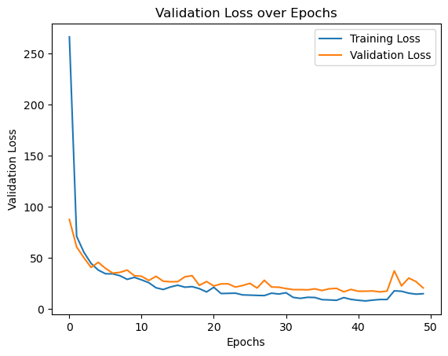

```python
import numpy as np
from sklearn.model_selection import KFold
from sklearn.decomposition import PCA

def create_model():
    # Initialize the ANN model
    model = tf.keras.models.Sequential()

    # Input Layer
    model.add(tf.keras.layers.Dense(units=692, activation='relu'))

    # Hidden Layers with Dropout and Regularization
    model.add(tf.keras.layers.Dense(1200, activation='relu', kernel_regularizer=tf.keras.regularizers.l2(0.01)))
    model.add(tf.keras.layers.Dense(600, activation='relu', kernel_regularizer=tf.keras.regularizers.l2(0.01)))
    model.add(tf.keras.layers.Dense(150, activation='relu', kernel_regularizer=tf.keras.regularizers.l2(0.01)))

    # Output Layer
    model.add(tf.keras.layers.Dense(1, activation='linear'))
    # Compile the model
    model.compile(optimizer='adam', loss='mean_squared_error', metrics=['mae'])
    return model

# Initialize and train the ANN model
ann_model = create_model()  # Create the model as defined earlier

# Train the model and capture the history object
history = ann_model.fit(X_train_scaled, y_train, epochs=50, batch_size=32, validation_data=(X_test_scaled, y_test))

# Predict on train and test data
y_ann_pred_train = ann_model.predict(X_train_scaled)
y_ann_pred_test = ann_model.predict(X_test_scaled)

# Calculate R² score for both training and test sets
r2_train_ann = r2_score(y_train, y_ann_pred_train)
r2_test_ann = r2_score(y_test, y_ann_pred_test)

# Print results
print(f"ANN Training R² score: {r2_train_ann:.4f}")
print(f"ANN Test R² score: {r2_test_ann:.4f}")

# Plot the validation loss
plt.plot(history.history['loss'], label='Training Loss')  # Training loss
plt.plot(history.history['val_loss'], label='Validation Loss')
plt.title('Validation Loss over Epochs')
plt.xlabel('Epochs')
plt.ylabel('Validation Loss')
plt.legend()
plt.show()
```

## 3.5 Implement PCA

```
Explained variance ratio: [0.46868281 0.17640645]
```

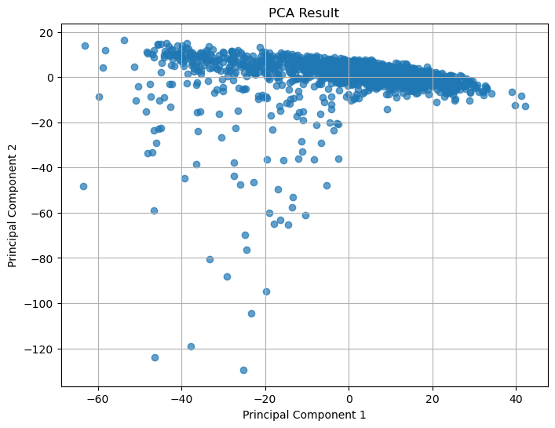

```python
from sklearn.decomposition import PCA
from sklearn.preprocessing import StandardScaler

# You can also concatenate your train and test data if needed for PCA fitting
# X = np.vstack((X_train, X_test))

# Standardize the data (important for PCA)
scaler = StandardScaler()
X_scaled = scaler.fit_transform(X_train)

# Initialize PCA
pca = PCA(n_components=2)  # Adjust the number of components as needed

# Fit PCA on the scaled data
X_pca = pca.fit_transform(X_scaled)

# Create a DataFrame for PCA results
pca_df = pd.DataFrame(data=X_pca, columns=['Principal Component 1', 'Principal Component 2'])

# Explained variance ratio
explained_variance = pca.explained_variance_ratio_
print(f'Explained variance ratio: {explained_variance}')

# Plotting the PCA results
plt.figure(figsize=(8, 6))
plt.scatter(pca_df['Principal Component 1'], pca_df['Principal Component 2'], alpha=0.7)
plt.title('PCA Result')
plt.xlabel('Principal Component 1')
plt.ylabel('Principal Component 2')
plt.grid()
plt.show()
```

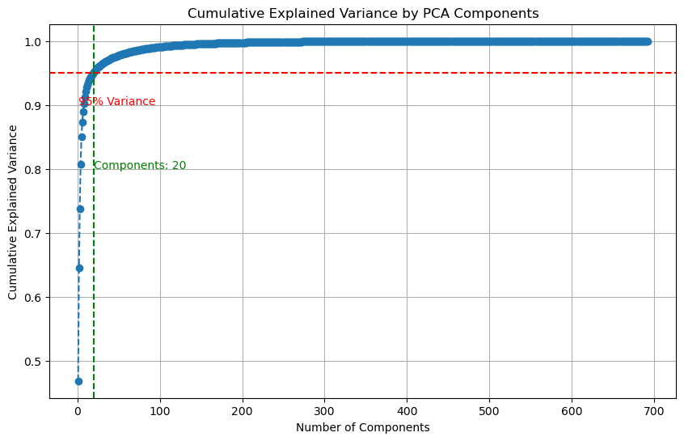

```
Number of components retained to achieve 95% variance: 20
```

```python
# Fit PCA again to get explained variance ratio
pca = PCA()
pca.fit(X_scaled)

# Plot the explained variance
plt.figure(figsize=(10, 6))
plt.plot(range(1, len(pca.explained_variance_ratio_) + 1),
         np.cumsum(pca.explained_variance_ratio_),
         marker='o', linestyle='--')
plt.title('Cumulative Explained Variance by PCA Components')
plt.xlabel('Number of Components')
plt.ylabel('Cumulative Explained Variance')
plt.axhline(y=0.95, color='r', linestyle='--')  # Line for 95% variance
plt.axvline(x=np.argmax(np.cumsum(pca.explained_variance_ratio_) >= 0.95) + 1, color='g', linestyle='--')  # Line for the number of components needed for 95%
plt.text(1, 0.9, '95% Variance', color='red')
plt.text(np.argmax(np.cumsum(pca.explained_variance_ratio_) >= 0.95) + 1, 0.8, f'Components: {np.argmax(np.cumsum(pca.explained_variance_ratio_) >= 0.95) + 1}', color='green')
plt.grid()
plt.show()

# Print the number of components used in PCA
n_components = np.argmax(np.cumsum(pca.explained_variance_ratio_) >= 0.95) + 1
print(f"Number of components retained to achieve 95% variance: {n_components}")
```

```python
#Reduce dimensionality

pca = PCA(n_components=n_components)
data_reduced = pca.fit_transform(X_scaled)
X_test_scaled = scaler.fit_transform(X_test)
test_reduced = pca.fit_transform(X_test_scaled)

data_reduced
```

```
array([[-2.71927851e+00,  4.65982905e+00,  2.11364734e+00, ...,
        -1.90770813e+00, -3.83473187e-01, -1.42072496e+00],
       [-1.19961441e+01, -6.05686993e+00,  1.11266442e+01, ...,
        -1.71805907e+00,  7.54905131e-01,  9.52234597e-01],
       [ 7.50983477e+00,  1.56927826e+00,  4.87162216e+00, ...,
         8.58006235e-01, -6.45233325e-02,  3.98903365e-01],
       ...,
       [ 7.94427452e+00,  5.91491907e+00, -7.55953842e+00, ...,
         1.76508784e-01,  1.62957593e+00, -3.75044402e-01],
       [ 1.91855896e+01, -4.72744029e-01, -8.49697344e+00, ...,
        -1.72026722e-02, -5.40436447e-01, -4.02971922e-01],
       [-2.38876432e+00, -2.09471538e+01,  1.25239729e+01, ...,
        -7.44947153e-01,  9.40450278e-01,  2.08209940e+00]])
```

## 3.6 Linear Regression with PCA

```python
from sklearn.linear_model import LinearRegression
# Apply linear regression
LinearRegModel = LinearRegression()
LinearRegModel.fit(data_reduced, y_train)

# Predict on test data
y_simple_pred_train = LinearRegModel.predict(data_reduced)
y_simple_pred_test = LinearRegModel.predict(test_reduced)

#Assess the accuracy of the model
# Calculate metrics (r2_score)
r2_train = r2_score(y_train, y_simple_pred_train)
r2_test = r2_score(y_test, y_simple_pred_test)

print(f"Training R² score: {r2_train:.4f}")
print(f"Test R² score: {r2_test:.4f}")
```

```
Training R² score: 0.6381
Test R² score: -1.7122
```

## 3.7 Polynomial Regression with PCA

```python
# Apply polynomial Regression

results = []

for degree in range(1, 3):
    #create and fit the polynomial regression model
    poly_reg = PolynomialFeatures(degree)
    X_poly = poly_reg.fit_transform(data_reduced)
    X_poly_test = poly_reg.transform(test_reduced)
    poly_model = LinearRegression()
    poly_model.fit(X_poly, y_train)

    # Make Predictions
    y_poly_pred_train = poly_model.predict(X_poly)
    y_poly_pred_test = poly_model.predict(X_poly_test)

    # Calculate metrics (r2_score)
    r2_train = r2_score(y_train, y_poly_pred_train)
    r2_test = r2_score(y_test, y_poly_pred_test)

    results.append({
        'Degree': degree,
        'R2 (Train)': r2_train,
        'R2 (Test)': r2_test
    })

    #Convert results to a DataFrame
    results_df = pd.DataFrame(results)

    # Find the best model based on test R2 score
    best_model = results_df.loc[results_df['R2 (Test)'].idxmax()]

# Set the display option for pandas to show floats with 3 decimal places
pd.options.display.float_format = '{:.4f}'.format

print("Best Index: ")
print(best_model)
print(results_df)
```

```
Best Index:
Degree        1.0000
R2 (Train)    0.6381
R2 (Test)    -1.7122
Name: 0, dtype: float64
   Degree  R2 (Train)  R2 (Test)
0       1      0.6381    -1.7122
1       2      0.7298    -2.2992
```

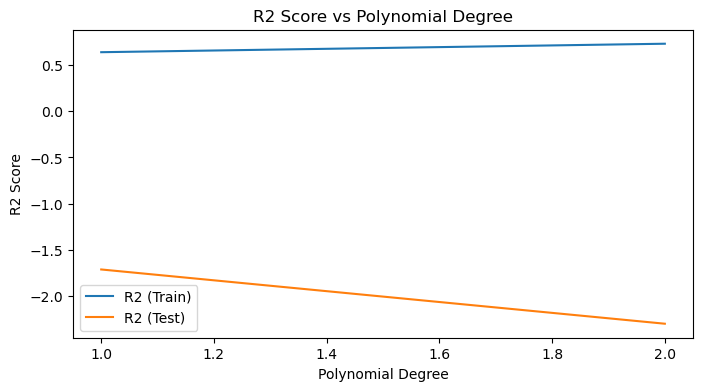

```python
plt.figure(figsize=(8,4))
plt.plot(results_df['Degree'], results_df['R2 (Train)'], label='R2 (Train)')
plt.plot(results_df['Degree'], results_df['R2 (Test)'], label='R2 (Test)')
plt.xlabel('Polynomial Degree')
plt.ylabel('R2 Score')
plt.title('R2 Score vs Polynomial Degree')
plt.legend()
plt.show()
```

## 3.8 ANN model with PCA

```
51/51 ━━━━━━━━━━━━━━━━━━━━ 3s 10ms/step - loss: 660.4255 - mae: 20.9873 - val_loss: 643.9191 - val_mae: 18.6911
51/51 ━━━━━━━━━━━━━━━━━━━━ 0s 6ms/step - loss: 78.9503 - mae: 6.6957 - val_loss: 543.4244 - val_mae: 18.0019
51/51 ━━━━━━━━━━━━━━━━━━━━ 0s 6ms/step - loss: 55.4144 - mae: 5.4642 - val_loss: 550.9156 - val_mae: 17.3631
51/51 ━━━━━━━━━━━━━━━━━━━━ 0s 7ms/step - loss: 48.3209 - mae: 5.0105 - val_loss: 445.5726 - val_mae: 15.4699
51/51 ━━━━━━━━━━━━━━━━━━━━ 0s 6ms/step - loss: 38.3765 - mae: 4.4186 - val_loss: 431.0177 - val_mae: 15.2680
51/51 ━━━━━━━━━━━━━━━━━━━━ 0s 6ms/step - loss: 33.4327 - mae: 4.0386 - val_loss: 386.8442 - val_mae: 14.2987
51/51 ━━━━━━━━━━━━━━━━━━━━ 0s 7ms/step - loss: 26.0415 - mae: 3.3871 - val_loss: 339.4573 - val_mae: 12.8916
51/51 ━━━━━━━━━━━━━━━━━━━━ 0s 6ms/step - loss: 21.9741 - mae: 3.0418 - val_loss: 273.3532 - val_mae: 11.7382
51/51 ━━━━━━━━━━━━━━━━━━━━ 0s 6ms/step - loss: 19.2555 - mae: 2.7471 - val_loss: 227.7100 - val_mae: 10.0500
51/51 ━━━━━━━━━━━━━━━━━━━━ 0s 6ms/step - loss: 18.6408 - mae: 2.6701 - val_loss: 172.9548 - val_mae: 9.0840
51/51 ━━━━━━━━━━━━━━━━━━━━ 0s 7ms/step - loss: 13.9941 - mae: 2.1349 - val_loss: 111.2805 - val_mae: 7.8350
51/51 ━━━━━━━━━━━━━━━━━━━━ 0s 5ms/step - loss: 13.9805 - mae: 2.2280 - val_loss: 92.4034 - val_mae: 7.1479
51/51 ━━━━━━━━━━━━━━━━━━━━ 0s 5ms/step - loss: 13.8260 - mae: 2.2496 - val_loss: 118.4709 - val_mae: 7.5911
51/51 ━━━━━━━━━━━━━━━━━━━━ 0s 7ms/step - loss: 10.8275 - mae: 1.7960 - val_loss: 100.9079 - val_mae: 6.8028
51/51 ━━━━━━━━━━━━━━━━━━━━ 0s 5ms/step - loss: 9.2275 - mae: 1.5323 - val_loss: 82.8504 - val_mae: 6.4511
51/51 ━━━━━━━━━━━━━━━━━━━━ 0s 6ms/step - loss: 10.0491 - mae: 1.7466 - val_loss: 119.1389 - val_mae: 6.8109
51/51 ━━━━━━━━━━━━━━━━━━━━ 0s 7ms/step - loss: 10.6376 - mae: 1.8698 - val_loss: 82.0959 - val_mae: 5.7949
51/51 ━━━━━━━━━━━━━━━━━━━━ 0s 5ms/step - loss: 10.8116 - mae: 1.9019 - val_loss: 88.4557 - val_mae: 6.0438
51/51 ━━━━━━━━━━━━━━━━━━━━ 0s 5ms/step - loss: 7.4634 - mae: 1.3158 - val_loss: 61.5019 - val_mae: 5.0895
51/51 ━━━━━━━━━━━━━━━━━━━━ 0s 5ms/step - loss: 7.4107 - mae: 1.3447 - val_loss: 79.6030 - val_mae: 5.6437
51/51 ━━━━━━━━━━━━━━━━━━━━ 0s 7ms/step - loss: 7.0194 - mae: 1.2841 - val_loss: 90.5613 - val_mae: 5.8785
51/51 ━━━━━━━━━━━━━━━━━━━━ 0s 5ms/step - loss: 8.6551 - mae: 1.6247 - val_loss: 78.8778 - val_mae: 5.3017
51/51 ━━━━━━━━━━━━━━━━━━━━ 0s 6ms/step - loss: 7.7391 - mae: 1.5143 - val_loss: 62.7657 - val_mae: 5.3675
51/51 ━━━━━━━━━━━━━━━━━━━━ 0s 7ms/step - loss: 6.6459 - mae: 1.2930 - val_loss: 74.1741 - val_mae: 5.5240
51/51 ━━━━━━━━━━━━━━━━━━━━ 0s 6ms/step - loss: 6.6202 - mae: 1.3205 - val_loss: 70.4830 - val_mae: 5.5455
51/51 ━━━━━━━━━━━━━━━━━━━━ 0s 6ms/step - loss: 6.9243 - mae: 1.4188 - val_loss: 66.8859 - val_mae: 5.2911
51/51 ━━━━━━━━━━━━━━━━━━━━ 0s 6ms/step - loss: 7.1097 - mae: 1.5102 - val_loss: 57.3074 - val_mae: 4.7511
51/51 ━━━━━━━━━━━━━━━━━━━━ 0s 6ms/step - loss: 6.2279 - mae: 1.3042 - val_loss: 56.2617 - val_mae: 4.9179
51/51 ━━━━━━━━━━━━━━━━━━━━ 0s 6ms/step - loss: 6.0183 - mae: 1.2982 - val_loss: 49.2303 - val_mae: 4.7828
51/51 ━━━━━━━━━━━━━━━━━━━━ 0s 6ms/step - loss: 6.4197 - mae: 1.4024 - val_loss: 60.7729 - val_mae: 5.2792
51/51 ━━━━━━━━━━━━━━━━━━━━ 0s 6ms/step - loss: 5.8766 - mae: 1.3056 - val_loss: 59.7021 - val_mae: 4.9692
51/51 ━━━━━━━━━━━━━━━━━━━━ 0s 5ms/step - loss: 5.7019 - mae: 1.2232 - val_loss: 59.7696 - val_mae: 4.8909
51/51 ━━━━━━━━━━━━━━━━━━━━ 0s 5ms/step - loss: 7.1628 - mae: 1.6158 - val_loss: 76.1023 - val_mae: 5.6895
51/51 ━━━━━━━━━━━━━━━━━━━━ 0s 7ms/step - loss: 7.6626 - mae: 1.7477 - val_loss: 79.1765 - val_mae: 5.4838
51/51 ━━━━━━━━━━━━━━━━━━━━ 0s 6ms/step - loss: 5.9794 - mae: 1.3953 - val_loss: 51.1572 - val_mae: 4.7290
51/51 ━━━━━━━━━━━━━━━━━━━━ 0s 5ms/step - loss: 4.8381 - mae: 1.1266 - val_loss: 76.5769 - val_mae: 5.4728
51/51 ━━━━━━━━━━━━━━━━━━━━ 0s 8ms/step - loss: 5.8167 - mae: 1.4192 - val_loss: 49.5795 - val_mae: 4.6370
51/51 ━━━━━━━━━━━━━━━━━━━━ 0s 5ms/step - loss: 4.5392 - mae: 1.0807 - val_loss: 69.9434 - val_mae: 5.3881
51/51 ━━━━━━━━━━━━━━━━━━━━ 0s 5ms/step - loss: 5.2586 - mae: 1.3137 - val_loss: 43.2610 - val_mae: 4.4812
51/51 ━━━━━━━━━━━━━━━━━━━━ 0s 7ms/step - loss: 4.7659 - mae: 1.2059 - val_loss: 58.6639 - val_mae: 4.9595
51/51 ━━━━━━━━━━━━━━━━━━━━ 0s 5ms/step - loss: 4.5798 - mae: 1.1630 - val_loss: 47.6923 - val_mae: 5.0673
51/51 ━━━━━━━━━━━━━━━━━━━━ 0s 6ms/step - loss: 5.8421 - mae: 1.4841 - val_loss: 65.7869 - val_mae: 5.7740
51/51 ━━━━━━━━━━━━━━━━━━━━ 0s 5ms/step - loss: 6.2268 - mae: 1.4554 - val_loss: 49.5785 - val_mae: 4.8448
51/51 ━━━━━━━━━━━━━━━━━━━━ 0s 6ms/step - loss: 5.5520 - mae: 1.4623 - val_loss: 55.5441 - val_mae: 5.0936
51/51 ━━━━━━━━━━━━━━━━━━━━ 0s 5ms/step - loss: 4.6260 - mae: 1.2192 - val_loss: 49.9455 - val_mae: 4.6166
51/51 ━━━━━━━━━━━━━━━━━━━━ 0s 5ms/step - loss: 4.4285 - mae: 1.1781 - val_loss: 50.9408 - val_mae: 4.8333
51/51 ━━━━━━━━━━━━━━━━━━━━ 0s 7ms/step - loss: 4.0141 - mae: 1.0716 - val_loss: 49.0385 - val_mae: 4.6079
51/51 ━━━━━━━━━━━━━━━━━━━━ 0s 6ms/step - loss: 4.1174 - mae: 1.1125 - val_loss: 42.7440 - val_mae: 4.5570
51/51 ━━━━━━━━━━━━━━━━━━━━ 0s 6ms/step - loss: 5.1228 - mae: 1.3661 - val_loss: 45.5692 - val_mae: 4.3990
51/51 ━━━━━━━━━━━━━━━━━━━━ 0s 7ms/step - loss: 4.9727 - mae: 1.3593 - val_loss: 43.6882 - val_mae: 4.6395
51/51 ━━━━━━━━━━━━━━━━━━━━ 0s 3ms/step
13/13 ━━━━━━━━━━━━━━━━━━━━ 0s 2ms/step
ANN Training R² score: 0.6354
ANN Test R² score: -5.4850
```

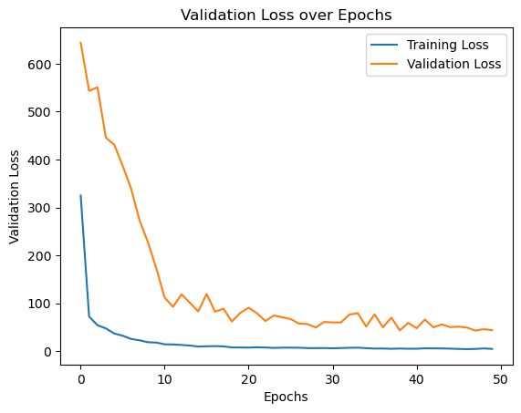

```python
import numpy as np
from sklearn.model_selection import KFold
from sklearn.decomposition import PCA

def create_model():
    # Initialize the ANN model
    model = tf.keras.models.Sequential()

    # Input Layer
    model.add(tf.keras.layers.Dense(units=20, activation='relu'))

    # Hidden Layers with Dropout and Regularization
    model.add(tf.keras.layers.Dense(1200, activation='relu', kernel_regularizer=tf.keras.regularizers.l2(0.01)))
    model.add(tf.keras.layers.Dense(600, activation='relu', kernel_regularizer=tf.keras.regularizers.l2(0.01)))
    model.add(tf.keras.layers.Dense(150, activation='relu', kernel_regularizer=tf.keras.regularizers.l2(0.01)))
    model.add(tf.keras.layers.Dense(50, activation='relu', kernel_regularizer=tf.keras.regularizers.l2(0.01)))
    model.add(tf.keras.layers.Dense(10, activation='relu', kernel_regularizer=tf.keras.regularizers.l2(0.01)))

    # Output Layer
    model.add(tf.keras.layers.Dense(1, activation='linear'))
    # Compile the model
    model.compile(optimizer='adam', loss='mean_squared_error', metrics=['mae'])
    return model

# Initialize and train the ANN model
ann_model = create_model()  # Create the model as defined earlier

# Train the model and capture the history object
history = ann_model.fit(data_reduced, y_train, epochs=50, batch_size=32, validation_data=(test_reduced, y_test))

# Predict on train and test data
y_ann_pred_train = ann_model.predict(data_reduced)
y_ann_pred_test = ann_model.predict(test_reduced)

# Calculate R² score for both training and test sets
r2_train_ann = r2_score(y_train, y_ann_pred_train)
r2_test_ann = r2_score(y_test, y_ann_pred_test)

# Print results
print(f"ANN Training R² score: {r2_train_ann:.4f}")
print(f"ANN Test R² score: {r2_test_ann:.4f}")

# Plot the validation loss
plt.plot(history.history['loss'], label='Training Loss')  # Training loss
plt.plot(history.history['val_loss'], label='Validation Loss')
plt.title('Validation Loss over Epochs')
plt.xlabel('Epochs')
plt.ylabel('Validation Loss')
plt.legend()
plt.show()
```

# 5. Conclusion

Potential issues with network architecture Insufficient regularization Extreme complexity of the dataset Possible data preprocessing requirements

Polynomial Regression was effectively abandoned due to computational constraints, with the code noting that the feature space exploded to 240,471 dimensions when attempting degree 2 polynomial transformation.

Linear Regression with PCA Linear regression was performed on the PCA-reduced data. The training R² score was 0.6381, which indicates that the model explains about 63.81% of the variance in the training data. However, the test R² score was significantly lower at -1.7122, suggesting poor generalization to the test data.

Polynomial Regression with PCA Polynomial regression was also applied to the PCA-reduced data with varying degrees of the polynomial. For degrees 1 and 2, the results showed the following:

Degree 1: The training R² score was 0.6381, and the test R² score was -1.7122, similar to the linear regression results. Degree 2: The training R² score improved to 0.7298, but the test R² score worsened further to -2.2992. The plot comparing the training and test R² scores across the polynomial degrees showed that as the degree of the polynomial increased, the model overfitted the training data, leading to worse performance on the test set.